# Prediction of hotel’s price in Vienna

Maeva_Braeckevelt

12/02/2021

# Summary

# Introduction

This analysis aimed at predicting the price of hotels in Vienna in order to find the best deals.The data used was gathered in a csv files : The hotels-vienna.csv. My predicted variable is the price in euro (y). My sample the hotels in Vienna in the weekday of November 2017.

# Data

## Label engineering

My predicted variable is the price of hotel in Euro. I kept only the price under 400 euro. The minimun price for a night is 27 euro and the maximum 384 euro. The mean is 122.9 euro. I observed that the distribution of the price is skewed with a right tail and some extreme values. I did not transform my y variable to simplify my interpretation of the residuals.

| Min. | 1st Qu. | Median | Mean | 3rd Qu. | Max. |
| --- | --- | --- | --- | --- | --- |
| 27 | 83 | 109 | 122.9 | 143 | 384 |

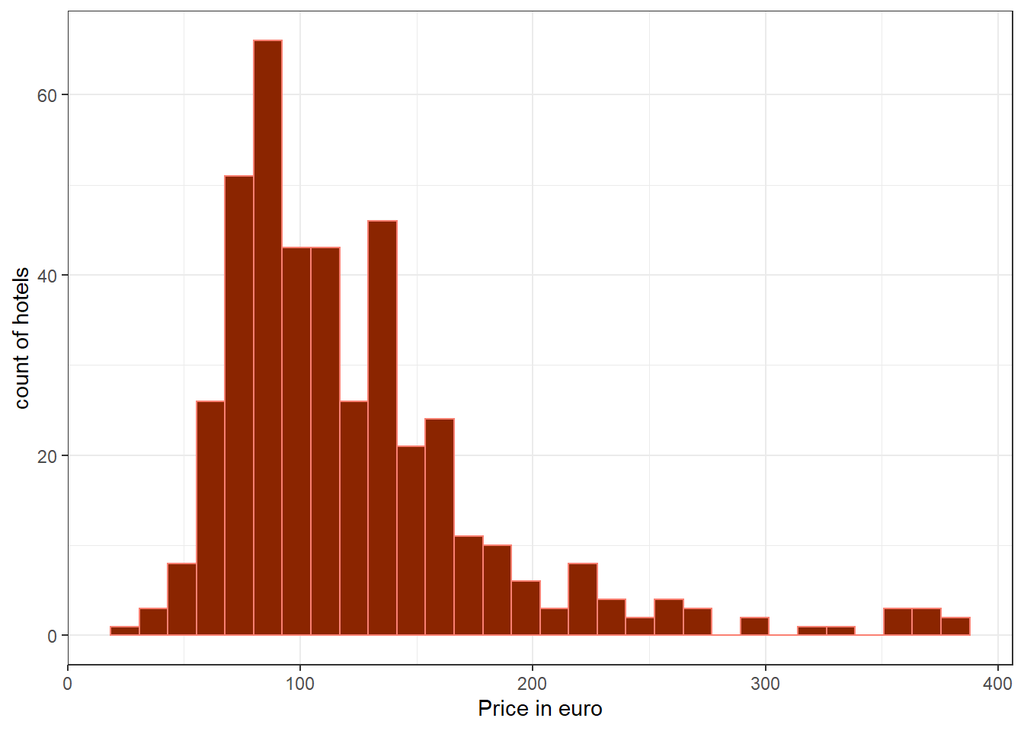

## Feature Engeneering

I decided to categorize my X variables in 4 categories :

**Location**

- Neigbhourhood : I factorized all the different neigbhourhood, and if a neigbhourhood appears less than 5 times in the sample, it is categorized as small_neigbhourhood.
- Distance : It is the distance from the city center, I only kept hotels that were maximum 5km away of the city center
- Distance_alter : It is the distance from the Donauturm.

**Rating**

- Stars : This variable shows the total of stars of the hotels
- Rating : It’s the user rating average, they were some missing values that I replace by 0, I did not flag them because, no other hotels had 0 as rating and I did not want to add variable if it was not needed
- Rating_count : It is the number of user ratings, they were some missing values that I replace by 0, I did not flag them because, no other hotels had 0 rating and I did not want to add variable if it was not needed
- Ratingta : It’s the user rating average from the website Tripadvisor, they were some missing values that I replace by 0, I did not flag them because, no other hotels had 0 as rating and I did not want to add variable if it was not needed
- Ratingta_count : It is the number of user ratings in the Tripadvisor website, they were some missing values that I replace by 0, I did not flag them because, no other hotels had 0 rating and I did not want to add variable if it was not needed

**Value**

- Scarce_room : This variable was flagged, if a room was noted as scarce
- Offer : This variable was flagged, if there was an offer available
- Offer_cat : Different categories of offers

**Interactions**

I choose my interactions with common knowledge :

- Distance with stars
- Distance_alter with stars
- Distance with rating
- Distance_alter with rating

I decided to keep only hotels as a type of accommodation and only those that were in the actual city of Vienna. My sample is composed by 246 observations.

# Models

I chose my models by gradually add more categories at each model.

- **X1** : Location
- **X2** : Location, *rating*
- **X3** : Location, rating, *value*
- **X4** : Location, rating, value, *interactions*

## Hold out set and cross validation

I will not do an holdhout set because I only have 246 observations and my goal is not to predict price for a live data but find the best deals in my actual data. However, I will do a 5-fold cross-validation to estimate models.

## Models

I used three different kind of models : OLS, CART and Random forest. For the OLS, I did a model with every predictors: X1,X2,X3 and X4. From the first table below, I observed the model 3 is the best model : it had the lowest RMSE, the second best Rsquare, and the second lowest BIC. I chose to use this model for the Cart and the Random Forest. After taking the average of all the folds of the cross validation, I got the result of the second table below. I observed that the Random forest had the lowest RMSE and the higher Rsquare of all models. I will rerun the model (with no cross validation) on all the sample, with the best parameters that I found : 5 mtry and 5 minimum node’size.

OLS

| rmse_test | rmse_train | model_name | model_pretty_name | nvars | r2 | BIC |
| --- | --- | --- | --- | --- | --- | --- |
| 49.44 | 44.75 | model1 | (1) | 17 | 0.4067 | 2678 |
| 42.31 | 36.46 | model2 | (2) | 22 | 0.6009 | 2608 |
| 41.75 | 35.46 | model3 | (3) | 26 | 0.6216 | 2617 |
| 43.99 | 34.66 | model4 | (4) | 30 | 0.6342 | 2631 |

Cart & Random forest

|  | Min. | 1st Qu. | Median | Mean | 3rd Qu. | Max. |
| --- | --- | --- | --- | --- | --- | --- |
| **CART_RMSE** | 35.98 | 38.2 | 38.38 | 40.92 | 40.16 | 51.87 |
| **RF_RMSE** | 29.09 | 29.7 | 29.95 | 34.66 | 34.27 | 50.29 |
| **CART_Rsquared** | 0.3034 | 0.4643 | 0.5854 | 0.5402 | 0.5923 | 0.7557 |
| **RF_Rsquared** | 0.3173 | 0.631 | 0.749 | 0.6574 | 0.7821 | 0.8077 |

# Prediction

With my final model, I found my predicted value for my y variable : the price of a room for one night. Find below, the graph of those two values. I observed than my prediction is close to the line, so my model is good.

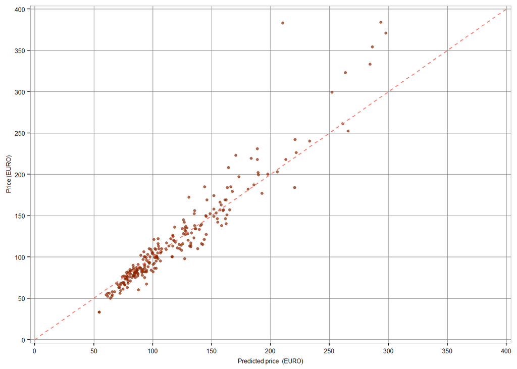

# Comparaison of the 5 best deals

I could then calculate the residuals : the difference between the real price and the predicted one. The five best deals of my sample, is the lowest residuals. Indeed, if there is a big negative difference between the actual price and the predicted price, it means that the hotels are cheaper than expected. Find below the 5 best deals of my sample compare to the 5 best deals we found in the chapter 10 with a different model.

Best deals for hotels - Random forest

| hotel_id | price | rf_prediction_res | distance | stars | rating |
| --- | --- | --- | --- | --- | --- |
| 22035 | 184 | -36.64 | 0.6 | 5 | 4.5 |
| 21984 | 98 | -29.05 | 0.5 | 3 | 3.7 |
| 22104 | 110 | -28.28 | 0.6 | 4 | 4.3 |
| 21912 | 60 | -28.04 | 1.1 | 4 | 4.1 |
| 22205 | 67 | -27.79 | 1.8 | 3 | 4 |

Best deals for hotels - Regression Chap10

| hotel_id | price | rf_prediction_res | distance | stars | rating |
| --- | --- | --- | --- | --- | --- |
| 21912 | 60 | -28.04 | 1.1 | 4 | 4.1 |
| 21975 | 115 | -27.46 | 0.1 | 4 | 4.3 |
| 22080 | 54 | -11.74 | 1.1 | 3 | 3.2 |
| 22184 | 75 | -18.32 | 0.7 | 3 | 4.1 |
| 22344 | 50 | -14.3 | 3.9 | 3 | 3.9 |

Best deals for 3 and 4 stars hotels - Random forest

| hotel_id | price | rf_prediction_res | distance | stars | rating |
| --- | --- | --- | --- | --- | --- |
| 21984 | 98 | -29.05 | 0.5 | 3 | 3.7 |
| 22104 | 110 | -28.28 | 0.6 | 4 | 4.3 |
| 21912 | 60 | -28.04 | 1.1 | 4 | 4.1 |
| 22205 | 67 | -27.79 | 1.8 | 3 | 4 |
| 21975 | 115 | -27.46 | 0.1 | 4 | 4.3 |

# Conclusion